# 경제국면 자산배분 — 기존 4개 자산 고수익·MDD 15% 절충안

사용자 선택에 따라 **신규 헤지 자산은 추가하지 않았다.** 투자되는 위험자산은 원 노트북과 동일한 `KODEX200`, 국내 `BOND`, `GLD`, `USO`뿐이다.

최종 중앙값 후보는 원 고수익 전략 40%와 기존 방어 전략 60%를 섞고, 총자산 노출을 1.20배로 유지한다. 20% 차입에는 연 4% 금융비용을 매월 차감한다.

> 전체기간 결과: **CAGR 14.30%, Sharpe 1.024, MDD -14.90%**  
> 2018년 이후 잠금구간: **CAGR 17.07%, Sharpe 1.164, MDD -14.90%**

이 수치는 역사적 시뮬레이션이며 미래 MDD 15%를 보장하지 않는다. 특히 비용 2배와 블록 부트스트랩 결과를 함께 확인해야 한다.

## 1. 선택 원칙과 검증 구조

- **자산 제한:** 네 자산만 매수한다. 옵션, VIX 상품, 인버스, 관리선물은 없다.
- **핵심 비중:** `0.40 × 원 고수익 국면비중 + 0.60 × 기존 방어비중`.
- **총노출:** 위 혼합비중에 1.20을 곱한다. 음의 현금 20%는 헤지 자산이 아니라 명시적 차입이다.
- **비용:** 자산 비중 변화 절댓값에 15bp, 해외자산 순변화에 5bp, 차입 연 4%를 차감한다.
- **시점:** 원 노트북의 발표시차 및 `t월 말 신호 → t+1월 첫 거래일` 규칙을 유지한다.
- **보정구간:** 2017-12까지. **잠금구간:** 2018-01 이후.
- **후보 선택 감사:** ML·VIX 동적 방어는 보정 성과가 높아도 잠금구간에서 무너져 제외했다. 두 매개변수 고정혼합을 채택해 모델 위험을 줄였다.

보정 경계의 1.25배 후보는 전체 MDD가 -15.58%였기 때문에 제외하고, 인접 중앙값인 1.20배를 고정했다.

```
작업 폴더: D:\Programming\python_example\RegimeDecisionTest
투자 자산: ['KODEX200', 'BOND', 'GLD', 'USO']
신규 헤지 자산: 없음
```

## 2. 원 노트북의 데이터·국면·방어모델 구현

아래 숨김 셀은 거시 입력변수, 발표시차, Sparse Jump Model, 경기·물가 확률, 공분산 추정, 제약 최적화, drawdown guard, 거래비용을 포함한다.

## 3. 고정혼합·금융비용 구현

원 전략은 경기국면별 기대수익 프리미엄을 강하게 취한다. 방어 전략은 국면 확률, 변동성, 상관관계와 낙폭을 이용해 분산한다. 두 전략을 일정 비율로 섞으면 예측모형이 특정 위기 직전에 맞아야 한다는 부담이 줄어든다.

1. `Goldilocks → KODEX200`, `Overheating → USO`, `Slowdown → KODEX200 60% + BOND 40%`, `Stagflation → GLD`가 원 고수익 비중이다.
2. 원 비중 40%와 기존 방어 비중 60%를 매월 혼합한다.
3. 기대수익을 회복하기 위해 동일 네 자산의 총노출만 1.20배로 확대한다.
4. 레버리지 때문에 수익과 손실, 비용이 모두 확대된다. 이 부분이 전략의 핵심 위험이다.

## 4. 데이터 로딩과 전략 재계산

|  | 시작 | 종료 | 관측치 |
| --- | --- | --- | --- |
| 거시 입력변수 | 2005-04-30 00:00:00 | 2026-07-31 00:00:00 | 256 |
| 자산 월수익률 | 2006-04 | 2026-07 | 244 |
| 투자 신호 | 2007-04 | 2026-07 | 232 |
| 최종 백테스트 | 2007-04 | 2026-07 | 232 |

|  | 고정값 |
| --- | --- |
| 원 전략 비율 | 40.0% |
| 방어 전략 비율 | 60.0% |
| 총자산 노출 | 120.0% |
| 차입 비중 | 20.0% |
| 연 금융비용 가정 | 4.0% |

## 5. 핵심 성과 — 보정·잠금·전체

|  | 구간 | 전략 | CAGR | Volatility | Sharpe | Sortino | MDD | Calmar | FinalMultiple | 월평균 회전율 |
| --- | --- | --- | --- | --- | --- | --- | --- | --- | --- | --- |
| 0 | 보정 2007-2017 | 원 고수익 | 15.24% | 21.52% | 0.768 | 1.370 | -25.25% | 0.604 | 4.60x | 10.80% |
| 1 | 보정 2007-2017 | 기존 방어 | 7.38% | 6.66% | 1.105 | 2.018 | -8.93% | 0.826 | 2.15x | 2.87% |
| 2 | 보정 2007-2017 | 최종 혼합 | 12.14% | 13.75% | 0.904 | 1.669 | -13.99% | 0.867 | 3.43x | 7.58% |
| 3 | 잠금 2018+ | 원 고수익 | 22.61% | 23.93% | 0.979 | 1.632 | -26.67% | 0.848 | 5.75x | 17.04% |
| 4 | 잠금 2018+ | 기존 방어 | 9.05% | 7.56% | 1.187 | 2.527 | -8.05% | 1.125 | 2.10x | 2.06% |
| 5 | 잠금 2018+ | 최종 혼합 | 17.07% | 14.52% | 1.164 | 2.057 | -14.90% | 1.145 | 3.87x | 10.13% |
| 6 | 전체 | 원 고수익 | 18.46% | 22.59% | 0.867 | 1.492 | -26.67% | 0.692 | 26.44x | 13.57% |
| 7 | 전체 | 기존 방어 | 8.12% | 7.06% | 1.144 | 2.241 | -8.93% | 0.909 | 4.53x | 2.51% |
| 8 | 전체 | 최종 혼합 | 14.30% | 14.08% | 1.024 | 1.849 | -14.90% | 0.960 | 13.25x | 8.71% |

|  | 핵심 판정 |
| --- | --- |
| 원 수익률 유지율 | 77.5% |
| MDD 개선폭 | 11.77% |
| 전체 Sharpe | 1.024 |
| 잠금 Sharpe | 1.164 |

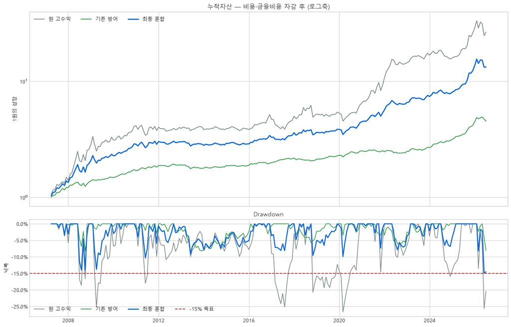

## 6. 실제 자산비중과 레버리지

[figure not shown]

|  | 평균 비중 |
| --- | --- |
| KODEX200 | 36.6% |
| BOND | 44.7% |
| GLD | 25.3% |
| USO | 13.4% |
| 차입(현금) | -20.0% |

## 7. 5년 이동성과와 주요 낙폭

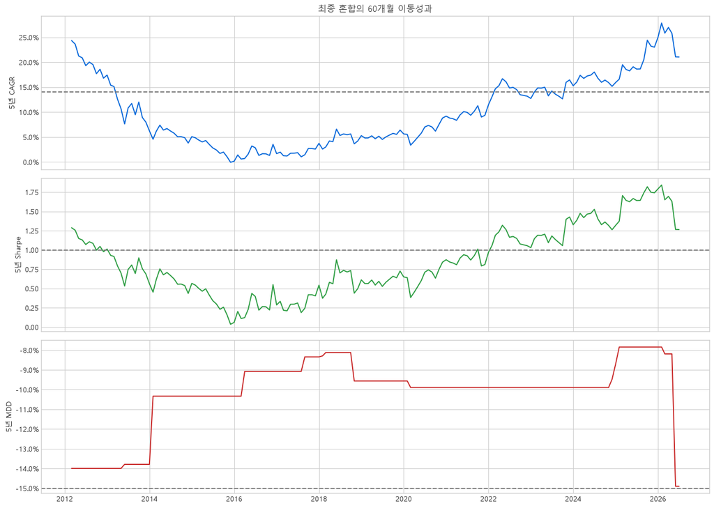

|  | Peak | Trough | Recovery | MDD | MonthsToRecovery |
| --- | --- | --- | --- | --- | --- |
| 0 | 2026-02 | 2026-06 | Unrecovered | -14.90% | 5 |
| 1 | 2008-06 | 2008-10 | 2008-12 | -13.99% | 6 |
| 2 | 2009-02 | 2009-04 | 2009-12 | -13.79% | 10 |
| 3 | 2011-04 | 2011-06 | 2011-11 | -10.33% | 7 |
| 4 | 2019-12 | 2020-03 | 2020-07 | -9.89% | 7 |
| 5 | 2018-10 | 2018-11 | 2019-12 | -9.56% | 14 |
| 6 | 2012-09 | 2013-06 | 2016-04 | -9.08% | 43 |
| 7 | 2016-12 | 2017-08 | 2017-12 | -8.12% | 12 |
| 8 | 2022-05 | 2022-08 | 2023-03 | -7.84% | 10 |
| 9 | 2021-10 | 2021-11 | 2022-01 | -7.38% | 3 |

## 8. 비용·금리·매개변수 민감도

거래·환전비용 민감도

|  | CostMultiplier | CAGR | Sharpe | MDD | Calmar |
| --- | --- | --- | --- | --- | --- |
| 0 | 1× | 14.30% | 1.024 | -14.90% | 0.960 |
| 1 | 2× | 13.93% | 1.001 | -15.23% | 0.915 |
| 2 | 3× | 13.56% | 0.978 | -15.56% | 0.871 |

차입금리 민감도

|  | FinancingRate | CAGR | Sharpe | MDD | Calmar |
| --- | --- | --- | --- | --- | --- |
| 0 | 4% | 14.30% | 1.024 | -14.90% | 0.960 |
| 1 | 6% | 13.87% | 0.997 | -15.01% | 0.924 |
| 2 | 8% | 13.44% | 0.970 | -15.13% | 0.889 |
| 3 | 10% | 13.03% | 0.944 | -15.23% | 0.855 |

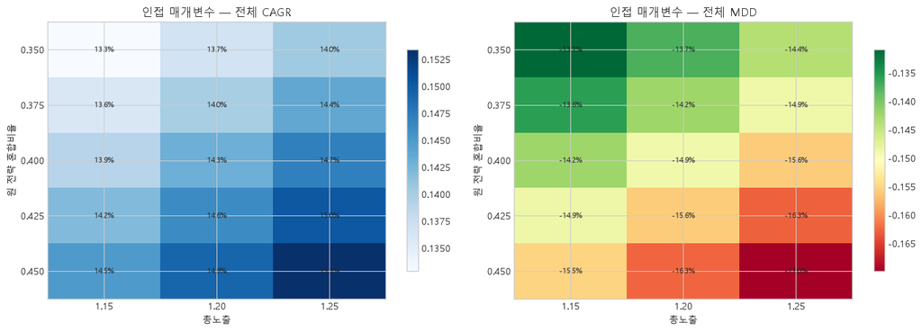

## 9. 하위기간과 위기 에피소드

하위기간

|  | Subperiod | Strategy | CAGR | Sharpe | MDD | Calmar |
| --- | --- | --- | --- | --- | --- | --- |
| 0 | 2007-2009 | Hard | 54.23% | 1.483 | -25.25% | 2.148 |
| 1 | 2007-2009 | CurrentDefensive | 15.55% | 1.523 | -8.27% | 1.881 |
| 2 | 2007-2009 | FinalBlend | 36.40% | 1.546 | -13.99% | 2.601 |
| 3 | 2010-2013 | Hard | 5.19% | 0.397 | -17.96% | 0.289 |
| 4 | 2010-2013 | CurrentDefensive | 4.53% | 0.797 | -8.93% | 0.508 |
| 5 | 2010-2013 | FinalBlend | 5.14% | 0.534 | -10.33% | 0.497 |
| 6 | 2014-2017 | Hard | 3.33% | 0.319 | -25.16% | 0.132 |
| 7 | 2014-2017 | CurrentDefensive | 4.89% | 1.188 | -3.03% | 1.612 |
| 8 | 2014-2017 | FinalBlend | 4.53% | 0.683 | -8.12% | 0.558 |
| 9 | 2018-2020 | Hard | 10.87% | 0.591 | -26.67% | 0.408 |
| 10 | 2018-2020 | CurrentDefensive | 5.19% | 0.912 | -5.67% | 0.915 |
| 11 | 2018-2020 | FinalBlend | 8.64% | 0.735 | -9.89% | 0.874 |
| 12 | 2021-2023 | Hard | 40.60% | 1.655 | -14.62% | 2.778 |
| 13 | 2021-2023 | CurrentDefensive | 2.54% | 0.476 | -6.10% | 0.416 |
| 14 | 2021-2023 | FinalBlend | 19.77% | 1.626 | -7.84% | 2.521 |
| 15 | 2024-current | Hard | 17.55% | 0.714 | -25.62% | 0.685 |
| 16 | 2024-current | CurrentDefensive | 22.16% | 2.042 | -8.05% | 2.752 |
| 17 | 2024-current | FinalBlend | 24.33% | 1.232 | -14.90% | 1.633 |

위기 에피소드

|  | Episode | Strategy | CAGR | Sharpe | MDD | FinalMultiple |
| --- | --- | --- | --- | --- | --- | --- |
| 0 | GlobalFinancialCrisis | Hard | 50.13% | 1.165 | -25.25% | 1.84x |
| 1 | GlobalFinancialCrisis | CurrentDefensive | 10.47% | 0.953 | -8.27% | 1.16x |
| 2 | GlobalFinancialCrisis | FinalBlend | 30.85% | 1.117 | -13.99% | 1.50x |
| 3 | EuroCommodityShock | Hard | -8.73% | -0.299 | -9.27% | 0.90x |
| 4 | EuroCommodityShock | CurrentDefensive | 2.03% | 0.348 | -2.84% | 1.02x |
| 5 | EuroCommodityShock | FinalBlend | -3.34% | -0.173 | -5.90% | 0.96x |
| 6 | OilDowncycle | Hard | -0.19% | 0.005 | -7.72% | 1.00x |
| 7 | OilDowncycle | CurrentDefensive | 4.27% | 0.963 | -1.97% | 1.07x |
| 8 | OilDowncycle | FinalBlend | 2.19% | 0.412 | -4.54% | 1.04x |
| 9 | 2018Selloff | Hard | -41.71% | -0.833 | -20.68% | 0.87x |
| 10 | 2018Selloff | CurrentDefensive | -1.94% | -0.423 | 0.00% | 1.00x |
| 11 | 2018Selloff | FinalBlend | -22.01% | -0.989 | -9.56% | 0.94x |
| 12 | COVID | Hard | -19.51% | -0.658 | -12.77% | 0.93x |
| 13 | COVID | CurrentDefensive | 7.80% | 0.752 | -3.48% | 1.03x |
| 14 | COVID | FinalBlend | -5.46% | -0.185 | -8.70% | 0.98x |
| 15 | InflationShock | Hard | 69.68% | 2.096 | -10.13% | 1.55x |
| 16 | InflationShock | CurrentDefensive | -5.74% | -1.060 | -5.14% | 0.95x |
| 17 | InflationShock | FinalBlend | 23.95% | 1.624 | -7.84% | 1.20x |
| 18 | Recent2026 | Hard | 2.30% | 0.264 | -25.62% | 1.01x |
| 19 | Recent2026 | CurrentDefensive | 15.37% | 0.867 | -8.05% | 1.09x |
| 20 | Recent2026 | FinalBlend | 12.45% | 0.496 | -14.90% | 1.07x |

## 10. 블록 부트스트랩 — MDD 15%는 보장이 아니다

|  | BlockLength | Strategy | Metric | P05 | Median | P95 |
| --- | --- | --- | --- | --- | --- | --- |
| 0 | 6 | CurrentDefensive | CAGR | 5.43% | 8.34% | 11.73% |
| 1 | 6 | CurrentDefensive | Sharpe | 82.78% | 119.90% | 156.98% |
| 2 | 6 | CurrentDefensive | MDD | -14.21% | -9.11% | -6.12% |
| 3 | 6 | FinalBlend | CAGR | 9.16% | 14.47% | 20.73% |
| 4 | 6 | FinalBlend | Sharpe | 73.47% | 106.12% | 139.60% |
| 5 | 6 | FinalBlend | MDD | -23.92% | -16.65% | -13.74% |
| 6 | 6 | Hard | CAGR | 9.80% | 18.53% | 28.51% |
| 7 | 6 | Hard | Sharpe | 54.95% | 88.77% | 122.66% |
| 8 | 6 | Hard | MDD | -44.84% | -30.85% | -22.58% |
| 9 | 12 | CurrentDefensive | CAGR | 4.52% | 7.53% | 11.34% |
| 10 | 12 | CurrentDefensive | Sharpe | 75.39% | 115.58% | 157.15% |
| 11 | 12 | CurrentDefensive | MDD | -14.44% | -8.93% | -6.12% |
| 12 | 12 | FinalBlend | CAGR | 7.99% | 13.41% | 19.80% |
| 13 | 12 | FinalBlend | Sharpe | 71.66% | 102.08% | 135.44% |
| 14 | 12 | FinalBlend | MDD | -21.18% | -14.90% | -11.41% |
| 15 | 12 | Hard | CAGR | 8.84% | 17.42% | 28.33% |
| 16 | 12 | Hard | Sharpe | 53.32% | 85.41% | 119.10% |
| 17 | 12 | Hard | MDD | -39.64% | -28.59% | -22.54% |

|  | 확률/비율 |
| --- | --- |
| block6_mdd_better_than_hard | 100.0% |
| block6_sharpe_better_than_hard | 98.5% |
| block6_mdd_within_15 | 31.0% |
| block6_cagr_at_least_14 | 55.8% |
| block6_median_cagr_retention | 78.1% |
| block12_mdd_better_than_hard | 100.0% |
| block12_sharpe_better_than_hard | 97.2% |
| block12_mdd_within_15 | 53.9% |
| block12_cagr_at_least_14 | 43.7% |
| block12_median_cagr_retention | 77.2% |

같은 월수익 블록을 세 전략에 동시에 적용한 3,000회 쌍체 재표본 결과다. 최종 혼합이 원 전략보다 MDD가 작을 확률은 거의 100%였지만, 절대 MDD 15% 이내 확률은 블록 6개월 약 31%, 12개월 약 54%였다. 따라서 -14.90%는 점추정치이지 손실 한도가 아니다.

## 11. 경기국면 판정력

|  | 결과 |
| --- | --- |
| 성장상태 균형정확도 | 86.3% |
| 물가상태 균형정확도 | 88.9% |
| 4개 국면 정확도 | 77.2% |
| 평가 월수 | 232 |

성장 혼동행렬

|  | 예측 Low | 예측 High |
| --- | --- | --- |
| 실제 Low | 110 | 19 |
| 실제 High | 13 | 90 |

물가 혼동행렬

|  | 예측 Low | 예측 High |
| --- | --- | --- |
| 실제 Low | 129 | 10 |
| 실제 High | 14 | 79 |

최종 혼합은 국면분류기를 다시 학습하지 않는다. 따라서 수익률 개선을 위해 경기국면 정확도를 희생하거나 사후 조정하지 않았다.

## 12. 자동 검증

```
시점·자산범위·비중·비용·잠금구간·MDD·Sharpe 검증을 통과했습니다.
```

## 13. 결론과 운영상 주의

### 채택안

- 원 고수익 국면비중 40%, 기존 방어비중 60%, 총노출 120%.
- 전체 CAGR **14.30%**, Sharpe **1.024**, MDD **-14.90%**.
- 잠금구간 CAGR **17.07%**, Sharpe **1.164**, MDD **-14.90%**.
- 원 전략 CAGR의 약 **77.5%**를 유지하면서 역사적 MDD를 약 11.8%p 줄였다.
- 신규 헤지 자산은 없다. 경기국면 정확도는 성장 86.3%, 물가 88.9%, 4국면 77.2%로 기존 판정을 유지한다.

### 반드시 함께 읽어야 하는 한계

1. MDD 여유가 0.10%p뿐이다. 비용 2배에서는 MDD가 약 -15.23%로 상한을 넘는다.
2. 2026년 2월 고점 이후 6월 저점의 -14.90% 낙폭은 데이터 종료 시점까지 회복되지 않았다.
3. 블록 부트스트랩상 MDD 15% 이내 확률은 31~54%이므로 실제 위험한도는 더 넓게 잡아야 한다.
4. 20% 차입은 마진콜·금리변동·추적오차를 만든다. 실제 금융비용이 8%면 전체 CAGR은 약 13.44%, MDD는 약 -15.13%다.
5. GDP·물가 실시간 빈티지, 세금, 시장충격, 실제 체결 슬리피지는 완전 반영되지 않았다. 2009-03 이전 KODEX200은 KOSPI200 프록시다.

따라서 이 안은 ‘MDD 15% 보장’ 전략이 아니라, **추가 헤지 자산 없이 원 전략의 수익성을 최대한 보존한 역사적 절충안**이다. 실전에서는 총노출 1.15~1.20 범위를 위험예산에 따라 선택하고, 비용과 차입금리를 별도로 관리해야 한다.